# Analysis of temporal trends in southern resident killer whales

This is version 0.18.07.31.

# 1 Requirements

All analyses require the [R software](https://cran.r-project.org/) (v3.4+) for data retrieval, data processing, and summarizing model results. We also need a few packages that are not included with the base installation of R, so we begin by installing them (if necessary) and then loading them.

```r
if(!require("here")) {
  install.packages("here")
  library("here")
}
if(!require("readr")) {
  install.packages("readr")
  library("readr")
}
if(!require("ggplot2")) {
  install.packages("ggplot2")
  library("ggplot2")
}
## set directory locations
datadir <- here("data")
analdir <- here("analysis")
```

# 2 Data

## 2.1 Southern resident killer whales

The counts of southern resident killer whales (SRKW) come from the [Center for Whale Research](https://www.whaleresearch.com/orcasurvey), and are broken down by the three major groups: J, K and L pods.

```r
kw <- read_csv(file.path(datadir, "SRKW.csv"))
head(kw)
```

```
## # A tibble: 6 x 5
##    year     J     K     L   JKL
##   <int> <int> <int> <int> <int>
## 1  1976    16    15    40    71
## 2  1977    18    16    46    80
## 3  1978    18    16    46    80
## 4  1979    19    16    47    82
## 5  1980    19    16    49    84
## 6  1981    19    16    47    82
```

```r
n_yr <- nrow(kw)
```

## 2.2 Snake River spring Chinook

The counts of Snake River spring Chinook at Lower Granite Dam come from [Columbia Basin Research](http://www.cbr.washington.edu/dart/query/adult_annual_sum). I’ll divide them by 1000 to make them more similar in magnitude to the SRKW data.

```r
ss <- read_csv(file.path(datadir, "SRSS.csv"))
ss[,2] <- ss[,2]/1000
head(ss)
```

```
## # A tibble: 6 x 2
##    year  SRSS
##   <int> <dbl>
## 1  1976 20.5
## 2  1977 38.8
## 3  1978 41.0
## 4  1979  7.54
## 5  1980  5.46
## 6  1981 13.1
```

## 2.3 Puget Sound Chinook

```r
ps_raw <- read_csv(file.path(datadir, "PS_Chin.csv"))
head(ps_raw)
```

```
## # A tibble: 6 x 3
##   popn           year spawners
##   <chr>         <int>    <int>
## 1 Cascade River  2013      316
## 2 Cascade River  2012      495
## 3 Cascade River  2011      269
## 4 Cascade River  2010      337
## 5 Cascade River  2009      343
## 6 Cascade River  2008      289
```

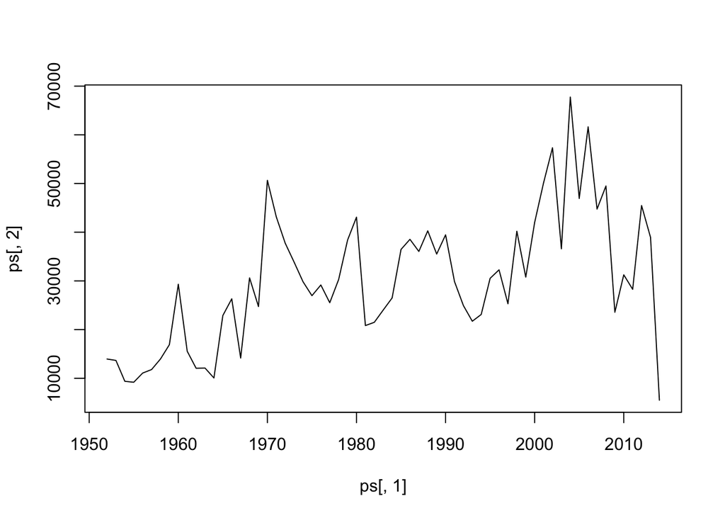

```r
ps <- aggregate(spawners ~ year, data = ps_raw, sum)
plot(ps[,1], ps[,2], type="l")
```

# 3 Plots

Here are plots of the time series of counts for orcas and salmon.

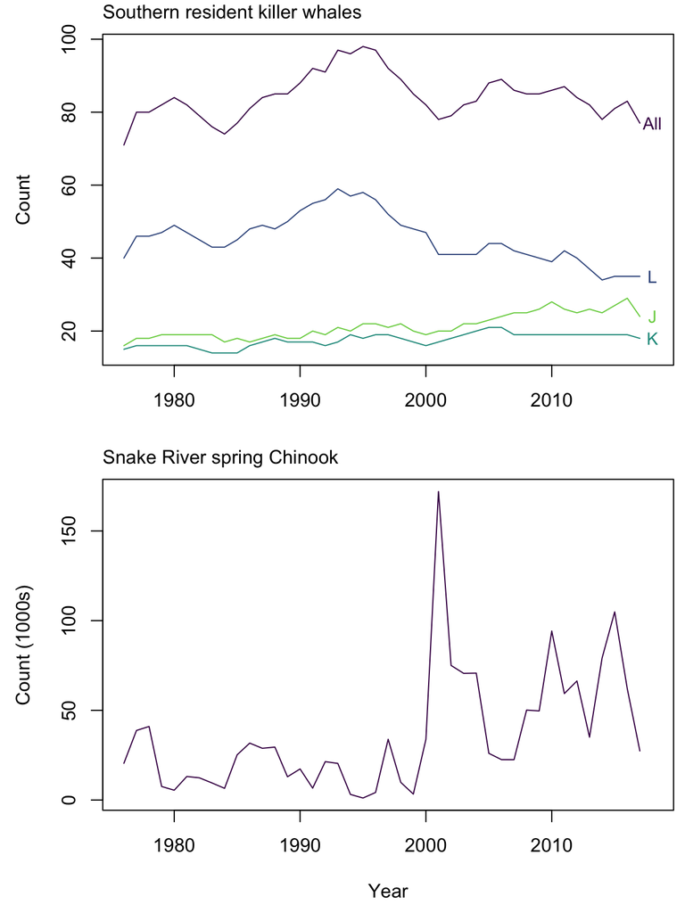

```r
par(mfrow=c(2,1), mai=c(0.8,0.8,0.2,0), omi=rep(0.1,4))
clr <- rev(viridis::viridis(4, end = 0.8))
## orcas
matplot(kw[,1], kw[,-1], type="l", lty="solid", xlim = c(kw[[1,1]], 2018),
        xlab = "", ylab = "Count", col = clr)
text(2018,kw[nrow(kw),-1],c("J","K","L","All"), cex=0.9, col = clr)
mtext("Southern resident killer whales", 3, adj=0, line=0.5)
## salmon
matplot(ss[,1], ss[,2], type="l", lty="solid", xlim = c(kw[[1,1]], 2018),
     xlab = "Year", ylab = "Count (1000s)", col = viridis::viridis(1))
mtext("Snake River spring Chinook", 3, adj=0, line=0.5)
```

It is perhaps more informative to look at the year-to-year differences in the counts of SRKW, as that gives an indication as to whether births exceed deaths.

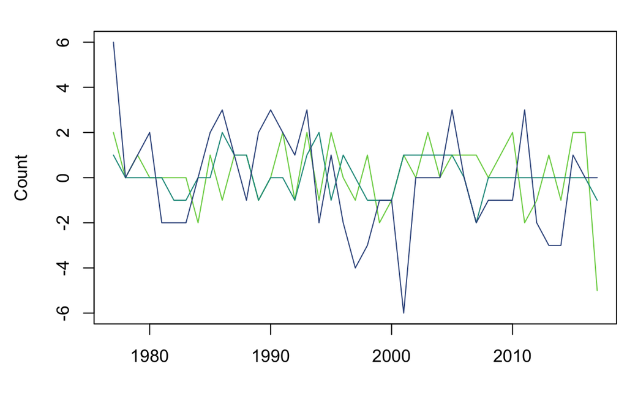

```r
## difference ts
kwd <- apply(kw[,2:4], 2, diff)
par(mai=c(0.8,0.8,0.2,0), omi=rep(0.1,4))
matplot(kw[-1,1], kwd, type="l", lty="solid",
        xlab = "", ylab = "Count", col = clr)
```

# 4 Correlations

Here are the correlations among the differenced counts of SRKW and SRSS Chinook.

```r
## raw counts of Chinook
round(cor(x = ss[-n_yr,2], y = kwd), 2)
```

```
##         J    K    L
## SRSS 0.07 0.24 0.06
```

```r
## log counts of Chinook
round(cor(x = log(ss[-n_yr,2]), y = kwd), 2)
```

```
##         J    K    L
## SRSS 0.11 0.23 0.09
```